# MGPs for univariate data at irregularly spaced locations

M Peruzzi

2022-01-27

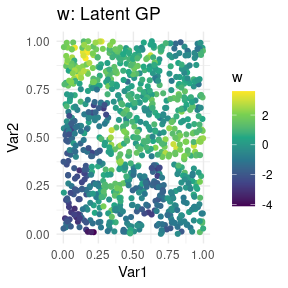

```r
library(magrittr)
library(dplyr)
library(ggplot2)
library(meshed)
set.seed(2021)

SS <- 30 # coord values for jth dimension
dd <- 2 # spatial dimension
n <- SS^2 # number of locations
p <- 3 # number of covariates

# irregularly spaced
coords <- cbind(runif(n), runif(n))
colnames(coords) <- c("Var1", "Var2")

sigmasq <- 1.5
nu <- 0.5
phi <- 10
tausq <- .1
ee <- rnorm(n) * tausq^.5

# covariance at coordinates
CC <- sigmasq * exp(-phi * as.matrix(dist(coords)))
# cholesky of covariance matrix
LC <- t(chol(CC))
# spatial latent effects are a GP
w <- LC %*% rnorm(n)

# covariates and coefficients
X <- matrix(rnorm(n*p), ncol=p)
Beta <- matrix(rnorm(p), ncol=1)

# univariate outcome, fully observed
y_full <- 1 + X %*% Beta + w + ee

# now introduce some NA values in the outcomes
y <- y_full %>% matrix(ncol=1)
y[sample(1:n, n/5, replace=FALSE), ] <- NA

simdata <- coords %>%
  cbind(data.frame(Outcome_full= y_full,
                   Outcome_obs = y,
                   w = w))

simdata %>% ggplot(aes(Var1, Var2, color=w)) +
    geom_point() +
    scale_color_viridis_c() +
  theme_minimal() + ggtitle("w: Latent GP")
```

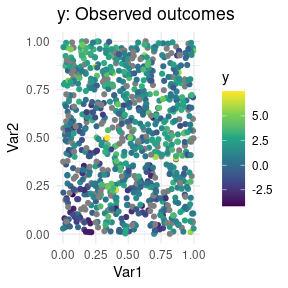

```r
simdata %>% ggplot(aes(Var1, Var2, color=y)) +
    geom_point() +
    scale_color_viridis_c() +
  theme_minimal() + ggtitle("y: Observed outcomes")
```

In `spmeshed` we can choose `settings$forced_grid=FALSE`, in which case we are fitting the model
$$y = X \beta + w + \epsilon,$$
where $w \sim MGP$ are spatial random effects and $\epsilon \sim N(0, \tau^2 I_n)$. If instead we choose `settings$forced_grid=TRUE`, then the model becomes
$$y = X \beta + H w + \epsilon',$$
where $w$ are now sampled on a grid of knots, $H$ is a matrix that interpolates $w$ to the observed locations, and $\epsilon \sim N(0, R + \tau^2 I_n)$ where $R$ is a diagonal matrix that corrects the measurement error variance. Refer to Peruzzi et al (2021)[^1] for details.

Regardless of the model chosen, for spatial data, an exponential covariance function is used by default: $C(h) = \sigma^2 \exp( -\phi h )$ where $h$ is the spatial distance.

The prior for the spatial decay $\phi$ is $U[l,u]$ and the values of $l$ and $u$ must be specified. We choose $l=1$, $u=30$ for this dataset.[^2]

Let’s start with the model without gridded knots.

```r
mcmc_keep <- 200 # too small! this is just a vignette.
mcmc_burn <- 400
mcmc_thin <- 2

mesh1_total_time <- system.time({
  meshout1 <- spmeshed(y, X, coords,
                      block_size = 25,
                      n_samples = mcmc_keep, n_burn = mcmc_burn, n_thin = mcmc_thin,
                      n_threads = 2,
                      verbose = 0,
                      settings=list(forced_grid=FALSE, cache=FALSE),
                      prior=list(phi=c(1,30))
  )})
```

And now with the gridded knots. We build a grid with as many knots as there are observations, but we could use a smaller or a bigger one.

```r
mesh2_total_time <- system.time({
  meshout2 <- spmeshed(y, X, coords,
                      grid_size = c(30, 30),
                      block_size = 25,
                      n_samples = mcmc_keep, n_burn = mcmc_burn, n_thin = mcmc_thin,
                      n_threads = 2,
                      verbose = 0,
                      prior=list(phi=c(1,30))
  )})
```

Post-processing proceeds the same way as when the data locations are on a grid. Let’s do that for the second model.

```r
summary(meshout2$lambda_mcmc[1,1,]^2)
```

```
#>    Min. 1st Qu.  Median    Mean 3rd Qu.    Max.
#>   1.452   2.668   3.507   4.141   5.081  10.164
```

```r
summary(meshout2$theta_mcmc[1,1,])
```

```
#>    Min. 1st Qu.  Median    Mean 3rd Qu.    Max.
#>   1.010   1.393   2.368   2.457   3.016   6.423
```

```r
summary(meshout2$tausq_mcmc[1,])
```

```
#>    Min. 1st Qu.  Median    Mean 3rd Qu.    Max.
#> 0.03712 0.12541 0.18388 0.19330 0.23855 0.41074
```

```r
summary(meshout2$beta_mcmc[1,1,])
```

```
#>    Min. 1st Qu.  Median    Mean 3rd Qu.    Max.
#>  -1.401  -1.349  -1.331  -1.332  -1.315  -1.263
```

We proceed to plot predictions across the domain along with the recovered latent effects. We plot the predictions at the input locations, i.e. the points not on the grid of knots, which we find via `forced_grid==0`. We plot the recovered latent process on the grid, for a nicer picture.

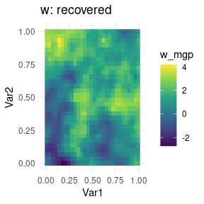

```r
# process means
wmesh <- data.frame(w_mgp = meshout2$w_mcmc %>% summary_list_mean())
# predictions
ymesh <- data.frame(y_mgp = meshout2$yhat_mcmc %>% summary_list_mean())

outdf <- meshout2$coordsdata %>%
  cbind(wmesh, ymesh) %>%
  left_join(simdata)

outdf %>% filter(forced_grid==1) %>%
    ggplot(aes(Var1, Var2, fill=w_mgp)) +
    geom_raster() +
    scale_fill_viridis_c() +
    theme_minimal() + ggtitle("w: recovered")
```

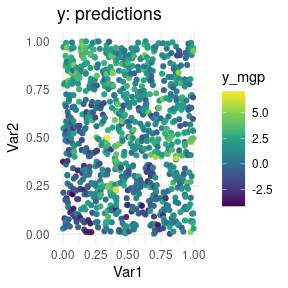

```r
outdf %>% filter(forced_grid==0) %>%
    ggplot(aes(Var1, Var2, color=y_mgp)) +
    geom_point() +
    scale_color_viridis_c() +
    theme_minimal() + ggtitle("y: predictions")
```

[^1]: https://arxiv.org/pdf/2101.03579.pdf
[^2]: `spmeshed` implements a model which can be interpreted as assigning $\sigma^2$ a folded-t via parameter expansion if `settings$ps=TRUE`, or an inverse Gamma with parameters $a=2$ and $b=1$ if `settings$ps=FALSE`, which cannot be changed at this time. $\tau^2$ is assigned an exponential prior.